# Optimal Treatment Analysis

## Outcome Variable

**Outcome Variable:** ever_wasted

## Predictor Variables

**Intervention Variable:** vagbrth

**Adjustment Set:**

- arm
- sex
- W_mage
- meducyrs
- feducyrs
- W_mhtcm
- W_mwtkg
- W_mbmi
- single
- brthmon
- W_parity
- delta_W_mage
- delta_meducyrs
- delta_feducyrs
- delta_W_mhtcm
- delta_W_mwtkg
- delta_W_mbmi
- delta_single
- delta_brthmon
- delta_W_parity

## Stratifying Variables

The analysis was stratified on these variable(s):

- agecat
- studyid
- country

## Data Summary

| agecat | studyid | country | vagbrth | ever_wasted | n_cell | n |
| --- | --- | --- | --- | --- | --- | --- |
| 0-24 months (no birth wast) | ki1000108-CMC-V-BCS-2002 | INDIA | 0 | 0 | 17 | 368 |
| 0-24 months (no birth wast) | ki1000108-CMC-V-BCS-2002 | INDIA | 0 | 1 | 8 | 368 |
| 0-24 months (no birth wast) | ki1000108-CMC-V-BCS-2002 | INDIA | 1 | 0 | 185 | 368 |
| 0-24 months (no birth wast) | ki1000108-CMC-V-BCS-2002 | INDIA | 1 | 1 | 158 | 368 |
| 0-24 months (no birth wast) | ki1000108-IRC | INDIA | 0 | 0 | 38 | 409 |
| 0-24 months (no birth wast) | ki1000108-IRC | INDIA | 0 | 1 | 32 | 409 |
| 0-24 months (no birth wast) | ki1000108-IRC | INDIA | 1 | 0 | 158 | 409 |
| 0-24 months (no birth wast) | ki1000108-IRC | INDIA | 1 | 1 | 181 | 409 |
| 0-24 months (no birth wast) | ki1017093b-PROVIDE | BANGLADESH | 0 | 0 | 132 | 687 |
| 0-24 months (no birth wast) | ki1017093b-PROVIDE | BANGLADESH | 0 | 1 | 27 | 687 |
| 0-24 months (no birth wast) | ki1017093b-PROVIDE | BANGLADESH | 1 | 0 | 433 | 687 |
| 0-24 months (no birth wast) | ki1017093b-PROVIDE | BANGLADESH | 1 | 1 | 95 | 687 |
| 0-24 months (no birth wast) | ki1017093c-NIH-Crypto | BANGLADESH | 0 | 0 | 181 | 496 |
| 0-24 months (no birth wast) | ki1017093c-NIH-Crypto | BANGLADESH | 0 | 1 | 21 | 496 |
| 0-24 months (no birth wast) | ki1017093c-NIH-Crypto | BANGLADESH | 1 | 0 | 245 | 496 |
| 0-24 months (no birth wast) | ki1017093c-NIH-Crypto | BANGLADESH | 1 | 1 | 49 | 496 |
| 0-24 months (no birth wast) | ki1066203-TanzaniaChild2 | TANZANIA, UNITED REPUBLIC OF | 0 | 0 | 174 | 2355 |
| 0-24 months (no birth wast) | ki1066203-TanzaniaChild2 | TANZANIA, UNITED REPUBLIC OF | 0 | 1 | 38 | 2355 |
| 0-24 months (no birth wast) | ki1066203-TanzaniaChild2 | TANZANIA, UNITED REPUBLIC OF | 1 | 0 | 1712 | 2355 |
| 0-24 months (no birth wast) | ki1066203-TanzaniaChild2 | TANZANIA, UNITED REPUBLIC OF | 1 | 1 | 431 | 2355 |
| 0-24 months (no birth wast) | ki1119695-PROBIT | BELARUS | 0 | 0 | 792 | 8113 |
| 0-24 months (no birth wast) | ki1119695-PROBIT | BELARUS | 0 | 1 | 55 | 8113 |
| 0-24 months (no birth wast) | ki1119695-PROBIT | BELARUS | 1 | 0 | 6824 | 8113 |
| 0-24 months (no birth wast) | ki1119695-PROBIT | BELARUS | 1 | 1 | 442 | 8113 |
| 0-24 months (no birth wast) | ki1126311-ZVITAMBO | ZIMBABWE | 0 | 0 | 941 | 12356 |
| 0-24 months (no birth wast) | ki1126311-ZVITAMBO | ZIMBABWE | 0 | 1 | 97 | 12356 |
| 0-24 months (no birth wast) | ki1126311-ZVITAMBO | ZIMBABWE | 1 | 0 | 10070 | 12356 |
| 0-24 months (no birth wast) | ki1126311-ZVITAMBO | ZIMBABWE | 1 | 1 | 1248 | 12356 |
| 0-24 months (no birth wast) | kiGH5241-JiVitA-3 | BANGLADESH | 0 | 0 | 653 | 12953 |
| 0-24 months (no birth wast) | kiGH5241-JiVitA-3 | BANGLADESH | 0 | 1 | 88 | 12953 |

[output cut: 78 more lines]

The following strata were considered:

- agecat: 0-24 months (no birth wast), studyid: ki1000108-CMC-V-BCS-2002, country: INDIA
- agecat: 0-24 months (no birth wast), studyid: ki1000108-IRC, country: INDIA
- agecat: 0-24 months (no birth wast), studyid: ki1017093b-PROVIDE, country: BANGLADESH
- agecat: 0-24 months (no birth wast), studyid: ki1017093c-NIH-Crypto, country: BANGLADESH
- agecat: 0-24 months (no birth wast), studyid: ki1066203-TanzaniaChild2, country: TANZANIA, UNITED REPUBLIC OF
- agecat: 0-24 months (no birth wast), studyid: ki1119695-PROBIT, country: BELARUS
- agecat: 0-24 months (no birth wast), studyid: ki1126311-ZVITAMBO, country: ZIMBABWE
- agecat: 0-24 months (no birth wast), studyid: kiGH5241-JiVitA-3, country: BANGLADESH
- agecat: 0-24 months (no birth wast), studyid: kiGH5241-JiVitA-4, country: BANGLADESH
- agecat: 0-6 months (no birth wast), studyid: ki1000108-CMC-V-BCS-2002, country: INDIA
- agecat: 0-6 months (no birth wast), studyid: ki1000108-IRC, country: INDIA
- agecat: 0-6 months (no birth wast), studyid: ki1017093b-PROVIDE, country: BANGLADESH
- agecat: 0-6 months (no birth wast), studyid: ki1017093c-NIH-Crypto, country: BANGLADESH
- agecat: 0-6 months (no birth wast), studyid: ki1066203-TanzaniaChild2, country: TANZANIA, UNITED REPUBLIC OF
- agecat: 0-6 months (no birth wast), studyid: ki1119695-PROBIT, country: BELARUS
- agecat: 0-6 months (no birth wast), studyid: ki1126311-ZVITAMBO, country: ZIMBABWE
- agecat: 0-6 months (no birth wast), studyid: kiGH5241-JiVitA-3, country: BANGLADESH
- agecat: 0-6 months (no birth wast), studyid: kiGH5241-JiVitA-4, country: BANGLADESH
- agecat: 6-24 months, studyid: ki1000108-CMC-V-BCS-2002, country: INDIA
- agecat: 6-24 months, studyid: ki1000108-IRC, country: INDIA
- agecat: 6-24 months, studyid: ki1017093b-PROVIDE, country: BANGLADESH
- agecat: 6-24 months, studyid: ki1017093c-NIH-Crypto, country: BANGLADESH
- agecat: 6-24 months, studyid: ki1066203-TanzaniaChild2, country: TANZANIA, UNITED REPUBLIC OF
- agecat: 6-24 months, studyid: ki1119695-PROBIT, country: BELARUS
- agecat: 6-24 months, studyid: ki1126311-ZVITAMBO, country: ZIMBABWE
- agecat: 6-24 months, studyid: kiGH5241-JiVitA-3, country: BANGLADESH
- agecat: 6-24 months, studyid: kiGH5241-JiVitA-4, country: BANGLADESH

### Dropped Strata

Some strata were dropped due to rare outcomes:

- agecat: 0-6 months (no birth wast), studyid: ki1017093c-NIH-Crypto, country: BANGLADESH
- agecat: 0-6 months (no birth wast), studyid: kiGH5241-JiVitA-4, country: BANGLADESH
- agecat: 6-24 months, studyid: ki1000108-CMC-V-BCS-2002, country: INDIA

## Methods Detail

We’re interested in the causal parameters $E[Y_a]$ for all values of $a \in \mathcal{A}$. These parameters represent the mean outcome if, possibly contrary to fact, we intervened to set all units to have $A=a$. Under the randomization and positivity assumptions, these are identified by the statistical parameters $\psi_a=E_W[E_{Y|A,W}(Y|A=a,W)]$. In addition, we’re interested in the mean of $Y$, $E[Y]$ under no intervention (the observed mean). We will estimate these parameters by using SuperLearner to fit the relevant likelihood factors – $E_{Y|A,W}(Y|A=a,W)$ and $p(A=a|W)$, and then updating our likelihood fit using a joint TMLE.

For unadjusted analyses ($W=\{\}$), initial likelihoods were estimated using Lrnr_glm to estimate the simple $E(Y|A)$ and Lrnr_mean to estimate $p(A)$. For adjusted analyses, a small library containing Lrnr_glmnet, Lrnr_xgboost, and Lrnr_mean was used.

Having estimated these parameters, we will then use the delta method to estimate relative risks and attributable risks relative to a prespecified baseline level of $A$.

# Results Detail

## Results Plots

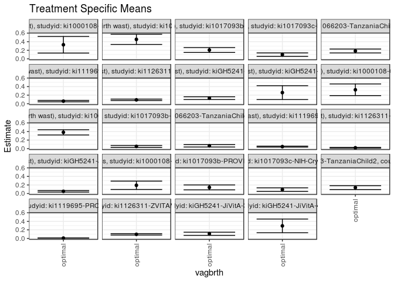

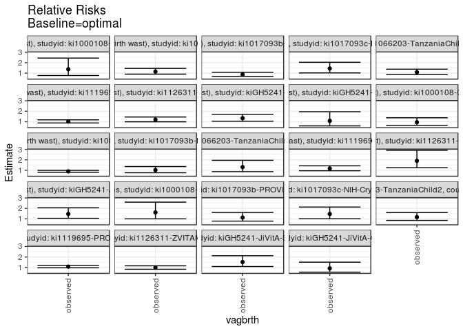

## Results Table

### Parameter: TSM

| agecat | studyid | country | intervention_level | baseline_level | estimate | ci_lower | ci_upper |
| --- | --- | --- | --- | --- | --- | --- | --- |
| 0-24 months (no birth wast) | ki1000108-CMC-V-BCS-2002 | INDIA | optimal | NA | 0.3284784 | 0.1343205 | 0.5226363 |
| 0-24 months (no birth wast) | ki1000108-IRC | INDIA | optimal | NA | 0.4543833 | 0.3358954 | 0.5728712 |
| 0-24 months (no birth wast) | ki1017093b-PROVIDE | BANGLADESH | optimal | NA | 0.2054806 | 0.1483755 | 0.2625856 |
| 0-24 months (no birth wast) | ki1017093c-NIH-Crypto | BANGLADESH | optimal | NA | 0.0978537 | 0.0576132 | 0.1380943 |
| 0-24 months (no birth wast) | ki1066203-TanzaniaChild2 | TANZANIA, UNITED REPUBLIC OF | optimal | NA | 0.1831230 | 0.1375291 | 0.2287169 |
| 0-24 months (no birth wast) | ki1119695-PROBIT | BELARUS | optimal | NA | 0.0601537 | 0.0440035 | 0.0763040 |
| 0-24 months (no birth wast) | ki1126311-ZVITAMBO | ZIMBABWE | optimal | NA | 0.0907316 | 0.0729336 | 0.1085296 |
| 0-24 months (no birth wast) | kiGH5241-JiVitA-3 | BANGLADESH | optimal | NA | 0.1303789 | 0.0977035 | 0.1630542 |
| 0-24 months (no birth wast) | kiGH5241-JiVitA-4 | BANGLADESH | optimal | NA | 0.2597613 | 0.0976977 | 0.4218248 |
| 0-6 months (no birth wast) | ki1000108-CMC-V-BCS-2002 | INDIA | optimal | NA | 0.3257982 | 0.1896751 | 0.4619214 |
| 0-6 months (no birth wast) | ki1000108-IRC | INDIA | optimal | NA | 0.3803397 | 0.3196702 | 0.4410092 |
| 0-6 months (no birth wast) | ki1017093b-PROVIDE | BANGLADESH | optimal | NA | 0.0517655 | 0.0292668 | 0.0742642 |
| 0-6 months (no birth wast) | ki1066203-TanzaniaChild2 | TANZANIA, UNITED REPUBLIC OF | optimal | NA | 0.0660599 | 0.0379800 | 0.0941398 |
| 0-6 months (no birth wast) | ki1119695-PROBIT | BELARUS | optimal | NA | 0.0472204 | 0.0358251 | 0.0586156 |
| 0-6 months (no birth wast) | ki1126311-ZVITAMBO | ZIMBABWE | optimal | NA | 0.0196975 | 0.0110985 | 0.0282966 |
| 0-6 months (no birth wast) | kiGH5241-JiVitA-3 | BANGLADESH | optimal | NA | 0.0512995 | 0.0335266 | 0.0690723 |
| 6-24 months | ki1000108-IRC | INDIA | optimal | NA | 0.1923939 | 0.0946075 | 0.2901802 |
| 6-24 months | ki1017093b-PROVIDE | BANGLADESH | optimal | NA | 0.1433708 | 0.0856845 | 0.2010570 |
| 6-24 months | ki1017093c-NIH-Crypto | BANGLADESH | optimal | NA | 0.0925031 | 0.0514410 | 0.1335652 |
| 6-24 months | ki1066203-TanzaniaChild2 | TANZANIA, UNITED REPUBLIC OF | optimal | NA | 0.1379101 | 0.0926323 | 0.1831879 |
| 6-24 months | ki1119695-PROBIT | BELARUS | optimal | NA | 0.0076910 | 0.0062955 | 0.0090865 |
| 6-24 months | ki1126311-ZVITAMBO | ZIMBABWE | optimal | NA | 0.0959419 | 0.0789980 | 0.1128857 |
| 6-24 months | kiGH5241-JiVitA-3 | BANGLADESH | optimal | NA | 0.1089668 | 0.0719071 | 0.1460265 |
| 6-24 months | kiGH5241-JiVitA-4 | BANGLADESH | optimal | NA | 0.2933324 | 0.1339568 | 0.4527081 |

### Parameter: E(Y)

| agecat | studyid | country | intervention_level | baseline_level | estimate | ci_lower | ci_upper |
| --- | --- | --- | --- | --- | --- | --- | --- |
| 0-24 months (no birth wast) | ki1000108-CMC-V-BCS-2002 | INDIA | observed | NA | 0.4510870 | 0.4001777 | 0.5019962 |
| 0-24 months (no birth wast) | ki1000108-IRC | INDIA | observed | NA | 0.5207824 | 0.4723080 | 0.5692568 |
| 0-24 months (no birth wast) | ki1017093b-PROVIDE | BANGLADESH | observed | NA | 0.1775837 | 0.1489858 | 0.2061816 |
| 0-24 months (no birth wast) | ki1017093c-NIH-Crypto | BANGLADESH | observed | NA | 0.1411290 | 0.1104588 | 0.1717993 |
| 0-24 months (no birth wast) | ki1066203-TanzaniaChild2 | TANZANIA, UNITED REPUBLIC OF | observed | NA | 0.1991507 | 0.1830179 | 0.2152836 |
| 0-24 months (no birth wast) | ki1119695-PROBIT | BELARUS | observed | NA | 0.0612597 | 0.0474556 | 0.0750638 |
| 0-24 months (no birth wast) | ki1126311-ZVITAMBO | ZIMBABWE | observed | NA | 0.1088540 | 0.1033621 | 0.1143459 |
| 0-24 months (no birth wast) | kiGH5241-JiVitA-3 | BANGLADESH | observed | NA | 0.1743226 | 0.1664929 | 0.1821522 |
| 0-24 months (no birth wast) | kiGH5241-JiVitA-4 | BANGLADESH | observed | NA | 0.2813559 | 0.2510454 | 0.3116665 |
| 0-6 months (no birth wast) | ki1000108-CMC-V-BCS-2002 | INDIA | observed | NA | 0.3085714 | 0.2601110 | 0.3570318 |
| 0-6 months (no birth wast) | ki1000108-IRC | INDIA | observed | NA | 0.3410256 | 0.2939169 | 0.3881343 |
| 0-6 months (no birth wast) | ki1017093b-PROVIDE | BANGLADESH | observed | NA | 0.0527086 | 0.0359384 | 0.0694789 |
| 0-6 months (no birth wast) | ki1066203-TanzaniaChild2 | TANZANIA, UNITED REPUBLIC OF | observed | NA | 0.0860673 | 0.0747182 | 0.0974164 |
| 0-6 months (no birth wast) | ki1119695-PROBIT | BELARUS | observed | NA | 0.0550194 | 0.0412334 | 0.0688054 |
| 0-6 months (no birth wast) | ki1126311-ZVITAMBO | ZIMBABWE | observed | NA | 0.0374284 | 0.0339371 | 0.0409198 |
| 0-6 months (no birth wast) | kiGH5241-JiVitA-3 | BANGLADESH | observed | NA | 0.0754024 | 0.0701103 | 0.0806945 |
| 6-24 months | ki1000108-IRC | INDIA | observed | NA | 0.3097561 | 0.2649438 | 0.3545684 |
| 6-24 months | ki1017093b-PROVIDE | BANGLADESH | observed | NA | 0.1609756 | 0.1319065 | 0.1900447 |
| 6-24 months | ki1017093c-NIH-Crypto | BANGLADESH | observed | NA | 0.1355932 | 0.1046749 | 0.1665115 |
| 6-24 months | ki1066203-TanzaniaChild2 | TANZANIA, UNITED REPUBLIC OF | observed | NA | 0.1608216 | 0.1447012 | 0.1769421 |
| 6-24 months | ki1119695-PROBIT | BELARUS | observed | NA | 0.0082759 | 0.0065972 | 0.0099545 |
| 6-24 months | ki1126311-ZVITAMBO | ZIMBABWE | observed | NA | 0.0936351 | 0.0880903 | 0.0991799 |
| 6-24 months | kiGH5241-JiVitA-3 | BANGLADESH | observed | NA | 0.1651010 | 0.1559407 | 0.1742613 |
| 6-24 months | kiGH5241-JiVitA-4 | BANGLADESH | observed | NA | 0.2653749 | 0.2359283 | 0.2948215 |

### Parameter: RR

| agecat | studyid | country | intervention_level | baseline_level | estimate | ci_lower | ci_upper |
| --- | --- | --- | --- | --- | --- | --- | --- |
| 0-24 months (no birth wast) | ki1000108-CMC-V-BCS-2002 | INDIA | observed | optimal | 1.3732620 | 0.7734707 | 2.4381641 |
| 0-24 months (no birth wast) | ki1000108-IRC | INDIA | observed | optimal | 1.1461301 | 0.9031130 | 1.4545403 |
| 0-24 months (no birth wast) | ki1017093b-PROVIDE | BANGLADESH | observed | optimal | 0.8642360 | 0.6901651 | 1.0822104 |
| 0-24 months (no birth wast) | ki1017093c-NIH-Crypto | BANGLADESH | observed | optimal | 1.4422447 | 1.0209872 | 2.0373124 |
| 0-24 months (no birth wast) | ki1066203-TanzaniaChild2 | TANZANIA, UNITED REPUBLIC OF | observed | optimal | 1.0875245 | 0.8578417 | 1.3787038 |
| 0-24 months (no birth wast) | ki1119695-PROBIT | BELARUS | observed | optimal | 1.0183860 | 0.8795705 | 1.1791095 |
| 0-24 months (no birth wast) | ki1126311-ZVITAMBO | ZIMBABWE | observed | optimal | 1.1997363 | 0.9929175 | 1.4496342 |
| 0-24 months (no birth wast) | kiGH5241-JiVitA-3 | BANGLADESH | observed | optimal | 1.3370459 | 1.0442705 | 1.7119049 |
| 0-24 months (no birth wast) | kiGH5241-JiVitA-4 | BANGLADESH | observed | optimal | 1.0831328 | 0.6006902 | 1.9530479 |
| 0-6 months (no birth wast) | ki1000108-CMC-V-BCS-2002 | INDIA | observed | optimal | 0.9471243 | 0.6521071 | 1.3756090 |
| 0-6 months (no birth wast) | ki1000108-IRC | INDIA | observed | optimal | 0.8966342 | 0.8105091 | 0.9919111 |
| 0-6 months (no birth wast) | ki1017093b-PROVIDE | BANGLADESH | observed | optimal | 1.0182191 | 0.7649645 | 1.3553178 |
| 0-6 months (no birth wast) | ki1066203-TanzaniaChild2 | TANZANIA, UNITED REPUBLIC OF | observed | optimal | 1.3028678 | 0.8693396 | 1.9525910 |
| 0-6 months (no birth wast) | ki1119695-PROBIT | BELARUS | observed | optimal | 1.1651628 | 0.9537233 | 1.4234782 |
| 0-6 months (no birth wast) | ki1126311-ZVITAMBO | ZIMBABWE | observed | optimal | 1.9001595 | 1.2410461 | 2.9093248 |
| 0-6 months (no birth wast) | kiGH5241-JiVitA-3 | BANGLADESH | observed | optimal | 1.4698478 | 1.0506559 | 2.0562893 |
| 6-24 months | ki1000108-IRC | INDIA | observed | optimal | 1.6100102 | 0.9979749 | 2.5973930 |
| 6-24 months | ki1017093b-PROVIDE | BANGLADESH | observed | optimal | 1.1227925 | 0.7845018 | 1.6069601 |
| 6-24 months | ki1017093c-NIH-Crypto | BANGLADESH | observed | optimal | 1.4658237 | 1.0091673 | 2.1291206 |
| 6-24 months | ki1066203-TanzaniaChild2 | TANZANIA, UNITED REPUBLIC OF | observed | optimal | 1.1661340 | 0.8523137 | 1.5955023 |
| 6-24 months | ki1119695-PROBIT | BELARUS | observed | optimal | 1.0760420 | 0.9614063 | 1.2043466 |
| 6-24 months | ki1126311-ZVITAMBO | ZIMBABWE | observed | optimal | 0.9759563 | 0.8262885 | 1.1527337 |
| 6-24 months | kiGH5241-JiVitA-3 | BANGLADESH | observed | optimal | 1.5151490 | 1.0844458 | 2.1169121 |
| 6-24 months | kiGH5241-JiVitA-4 | BANGLADESH | observed | optimal | 0.9046899 | 0.5454719 | 1.5004693 |

### Parameter: PAR

| agecat | studyid | country | intervention_level | baseline_level | estimate | ci_lower | ci_upper |
| --- | --- | --- | --- | --- | --- | --- | --- |
| 0-24 months (no birth wast) | ki1000108-CMC-V-BCS-2002 | INDIA | optimal | NA | 0.1226085 | -0.0657059 | 0.3109229 |
| 0-24 months (no birth wast) | ki1000108-IRC | INDIA | optimal | NA | 0.0663991 | -0.0417010 | 0.1744992 |
| 0-24 months (no birth wast) | ki1017093b-PROVIDE | BANGLADESH | optimal | NA | -0.0278969 | -0.0743744 | 0.0185807 |
| 0-24 months (no birth wast) | ki1017093c-NIH-Crypto | BANGLADESH | optimal | NA | 0.0432753 | 0.0083445 | 0.0782061 |
| 0-24 months (no birth wast) | ki1066203-TanzaniaChild2 | TANZANIA, UNITED REPUBLIC OF | optimal | NA | 0.0160278 | -0.0274645 | 0.0595200 |
| 0-24 months (no birth wast) | ki1119695-PROBIT | BELARUS | optimal | NA | 0.0011060 | -0.0077131 | 0.0099251 |
| 0-24 months (no birth wast) | ki1126311-ZVITAMBO | ZIMBABWE | optimal | NA | 0.0181224 | 0.0009372 | 0.0353076 |
| 0-24 months (no birth wast) | kiGH5241-JiVitA-3 | BANGLADESH | optimal | NA | 0.0439437 | 0.0116354 | 0.0762520 |
| 0-24 months (no birth wast) | kiGH5241-JiVitA-4 | BANGLADESH | optimal | NA | 0.0215947 | -0.1310090 | 0.1741983 |
| 0-6 months (no birth wast) | ki1000108-CMC-V-BCS-2002 | INDIA | optimal | NA | -0.0172268 | -0.1390964 | 0.1046428 |
| 0-6 months (no birth wast) | ki1000108-IRC | INDIA | optimal | NA | -0.0393141 | -0.0773585 | -0.0012697 |
| 0-6 months (no birth wast) | ki1017093b-PROVIDE | BANGLADESH | optimal | NA | 0.0009431 | -0.0138542 | 0.0157404 |
| 0-6 months (no birth wast) | ki1066203-TanzaniaChild2 | TANZANIA, UNITED REPUBLIC OF | optimal | NA | 0.0200074 | -0.0068594 | 0.0468742 |
| 0-6 months (no birth wast) | ki1119695-PROBIT | BELARUS | optimal | NA | 0.0077990 | -0.0026732 | 0.0182713 |
| 0-6 months (no birth wast) | ki1126311-ZVITAMBO | ZIMBABWE | optimal | NA | 0.0177309 | 0.0091872 | 0.0262747 |
| 0-6 months (no birth wast) | kiGH5241-JiVitA-3 | BANGLADESH | optimal | NA | 0.0241029 | 0.0068818 | 0.0413241 |
| 6-24 months | ki1000108-IRC | INDIA | optimal | NA | 0.1173622 | 0.0248439 | 0.2098805 |
| 6-24 months | ki1017093b-PROVIDE | BANGLADESH | optimal | NA | 0.0176049 | -0.0338772 | 0.0690870 |
| 6-24 months | ki1017093c-NIH-Crypto | BANGLADESH | optimal | NA | 0.0430901 | 0.0075069 | 0.0786733 |
| 6-24 months | ki1066203-TanzaniaChild2 | TANZANIA, UNITED REPUBLIC OF | optimal | NA | 0.0229116 | -0.0204031 | 0.0662262 |
| 6-24 months | ki1119695-PROBIT | BELARUS | optimal | NA | 0.0005848 | -0.0003418 | 0.0015115 |
| 6-24 months | ki1126311-ZVITAMBO | ZIMBABWE | optimal | NA | -0.0023068 | -0.0182790 | 0.0136654 |
| 6-24 months | kiGH5241-JiVitA-3 | BANGLADESH | optimal | NA | 0.0561342 | 0.0196196 | 0.0926487 |
| 6-24 months | kiGH5241-JiVitA-4 | BANGLADESH | optimal | NA | -0.0279575 | -0.1771405 | 0.1212254 |

### Parameter: PAF

| agecat | studyid | country | intervention_level | baseline_level | estimate | ci_lower | ci_upper |
| --- | --- | --- | --- | --- | --- | --- | --- |
| 0-24 months (no birth wast) | ki1000108-CMC-V-BCS-2002 | INDIA | optimal | NA | 0.2718068 | -0.2928738 | 0.5898553 |
| 0-24 months (no birth wast) | ki1000108-IRC | INDIA | optimal | NA | 0.1274987 | -0.1072812 | 0.3124976 |
| 0-24 months (no birth wast) | ki1017093b-PROVIDE | BANGLADESH | optimal | NA | -0.1570914 | -0.4489287 | 0.0759652 |
| 0-24 months (no birth wast) | ki1017093c-NIH-Crypto | BANGLADESH | optimal | NA | 0.3066364 | 0.0205558 | 0.5091573 |
| 0-24 months (no birth wast) | ki1066203-TanzaniaChild2 | TANZANIA, UNITED REPUBLIC OF | optimal | NA | 0.0804805 | -0.1657162 | 0.2746810 |
| 0-24 months (no birth wast) | ki1119695-PROBIT | BELARUS | optimal | NA | 0.0180540 | -0.1369185 | 0.1519023 |
| 0-24 months (no birth wast) | ki1126311-ZVITAMBO | ZIMBABWE | optimal | NA | 0.1664835 | -0.0071330 | 0.3101708 |
| 0-24 months (no birth wast) | kiGH5241-JiVitA-3 | BANGLADESH | optimal | NA | 0.2520825 | 0.0423938 | 0.4158554 |
| 0-24 months (no birth wast) | kiGH5241-JiVitA-4 | BANGLADESH | optimal | NA | 0.0767522 | -0.6647518 | 0.4879798 |
| 0-6 months (no birth wast) | ki1000108-CMC-V-BCS-2002 | INDIA | optimal | NA | -0.0558276 | -0.5334904 | 0.2730493 |
| 0-6 months (no birth wast) | ki1000108-IRC | INDIA | optimal | NA | -0.1152820 | -0.2337924 | -0.0081549 |
| 0-6 months (no birth wast) | ki1017093b-PROVIDE | BANGLADESH | optimal | NA | 0.0178931 | -0.3072502 | 0.2621657 |
| 0-6 months (no birth wast) | ki1066203-TanzaniaChild2 | TANZANIA, UNITED REPUBLIC OF | optimal | NA | 0.2324624 | -0.1502985 | 0.4878600 |
| 0-6 months (no birth wast) | ki1119695-PROBIT | BELARUS | optimal | NA | 0.1417508 | -0.0485222 | 0.2974954 |
| 0-6 months (no birth wast) | ki1126311-ZVITAMBO | ZIMBABWE | optimal | NA | 0.4737284 | 0.1942281 | 0.6562776 |
| 0-6 months (no birth wast) | kiGH5241-JiVitA-3 | BANGLADESH | optimal | NA | 0.3196574 | 0.0482136 | 0.5136871 |
| 6-24 months | ki1000108-IRC | INDIA | optimal | NA | 0.3788859 | -0.0020292 | 0.6149986 |
| 6-24 months | ki1017093b-PROVIDE | BANGLADESH | optimal | NA | 0.1093635 | -0.2746944 | 0.3777070 |
| 6-24 months | ki1017093c-NIH-Crypto | BANGLADESH | optimal | NA | 0.3177897 | 0.0090841 | 0.5303225 |
| 6-24 months | ki1066203-TanzaniaChild2 | TANZANIA, UNITED REPUBLIC OF | optimal | NA | 0.1424656 | -0.1732769 | 0.3732381 |
| 6-24 months | ki1119695-PROBIT | BELARUS | optimal | NA | 0.0706682 | -0.0401430 | 0.1696742 |
| 6-24 months | ki1126311-ZVITAMBO | ZIMBABWE | optimal | NA | -0.0246361 | -0.2102311 | 0.1324970 |
| 6-24 months | kiGH5241-JiVitA-3 | BANGLADESH | optimal | NA | 0.3399989 | 0.0778700 | 0.5276138 |
| 6-24 months | kiGH5241-JiVitA-4 | BANGLADESH | optimal | NA | -0.1053511 | -0.8332751 | 0.3335418 |